# ClimateChangeProject

By Francisco Soltero

```python
import pandas as pd
import numpy as np
import matplotlib.pyplot as plt
import string
import re

pd.options.mode.copy_on_write = True
np.random.seed(1)
```

```python
from google.colab import drive
drive.mount('/content/drive')
%cd /content/drive/MyDrive/Colab\ Notebooks/FinalizedData
%ls
```

```
/content/drive/MyDrive/Colab Notebooks/FinalizedData
GlobalLandTemperaturesByCity.csv       GlobalLandTemperaturesByState.csv
GlobalLandTemperaturesByCountry.csv    GlobalTemperatures.csv
GlobalLandTemperaturesByMajorCity.csv
```

```python
#%%shell
#cd ..
#ls
#jupyter nbconvert ClimateChangeProject.ipynb --to html
```

[output not shown]

**Project Goals**

The goal of this project is to investigate whether climate change is as bad as it seems. My data set consists of all the average land temperatures around the globe, by every major city, by every country, by every city, and by every state. The goal will be to identify if there is tremendous increase in temperature from 1750 to today and to identify what caused those temperature increases. The data is sourced from https://www.kaggle.com/datasets/berkeleyearth/climate-change-earth-surface-temperature-data?resource=download. My hypothesis is that every country, city, major city, state, and the world as a whole will have a fairly large temperature increase from the first recorded temperatures. With a goal in mind to try and predict the global increase and country increase for the future. Ideally a model that would be able to predict just how how it will be in 50 years from now.

**Website**: https://frankiesoltero.github.io/DataScienceProject/

**Data Frames**: Below in our code cell we see our 5 defined data frames.

global_temperatures: Contains the global temperatures from 1750 - 2015, we will use this for a future model to predict the temperature for years after 2015. Ideally would want to use a KNN model to predict the temp of the first of the month and from there compare it to the actual temperature of that day for the globe to validate the model

global_land_temps_bycity: This contains the land temperatures by city and the average temperature uncertainty for every city in the world. This data set will be useful to try and compare cities that are suffering from climate change. I would likely like to target a model that could predict what city you are in based on the date you are there and the temperature of that day.

global_land_temps_bycountry: This is the same idea as the city data frame, except it contains every country in the world. This will be very useful for identifying which country has had the overall largest increase in average temperature over time. Would be able to rank the best versus the worst countries in terms of biggest difference in temperature gain or loss.

global_land_temps_by_major_city: The same idea as per city except uses all the major cities in the world. This will be ideal for identifying major cities with high temperature increases and or decreases.

global_land_temps_by_state: Ideal for comparing the situations in regard to average temperature in the states. Will be useful for identifying what states are in the worst boat and if it has any correlation with their beliefs in climate change.

```python
import glob
import requests
from bs4 import BeautifulSoup

global_temperatures = pd.read_csv("GlobalTemperatures.csv")
global_land_temps_bycity = pd.read_csv("GlobalLandTemperaturesByCity.csv")
global_land_temps_bycountry = pd.read_csv("GlobalLandTemperaturesByCountry.csv")
global_land_temps_by_major_city = pd.read_csv("GlobalLandTemperaturesByMajorCity.csv")
global_land_temps_by_state = pd.read_csv("GlobalLandTemperaturesByState.csv")
```

**Data Types**:

Global Land Temperaure by State:

- dt DateTime Object
- AverageTemperature float64
- AverageTemperatureUncertainty float64
- State object
- Country object
- dtype: object

GLT by Major City:

- dt DateTime Object
- AverageTemperature float64
- AverageTemperatureUncertainty float64
- City object
- Country object
- Latitude object
- Longitude object
- dtype: object

GLT by Country:

- dt DateTime Object
- AverageTemperature float64
- AverageTemperatureUncertainty float64
- Country object
- dtype: object

GLT by City:

- dt DateTime Object
- AverageTemperature float64
- AverageTemperatureUncertainty float64
- City object
- Country object
- Latitude object
- Longitude object
- dtype: object

Global Temperatures:

- dt DateTime Object
- LandAverageTemperature float64
- LandAverageTemperatureUncertainty float64
- LandMaxTemperature float64
- LandMaxTemperatureUncertainty float64
- LandMinTemperature float64
- LandMinTemperatureUncertainty float64
- LandAndOceanAverageTemperature float64
- LandAndOceanAverageTemperatureUncertainty float64
- dtype: object

```python
data_frames = [global_land_temps_by_state, global_land_temps_by_major_city, global_land_temps_bycountry, global_land_temps_bycity, global_temperatures]
for df in data_frames:
  print(df.dtypes)
```

```
dt                                object
AverageTemperature               float64
AverageTemperatureUncertainty    float64
State                             object
Country                           object
dtype: object
dt                                object
AverageTemperature               float64
AverageTemperatureUncertainty    float64
City                              object
Country                           object
Latitude                          object
Longitude                         object
dtype: object
dt                                object
AverageTemperature               float64
AverageTemperatureUncertainty    float64
Country                           object
dtype: object
dt                                object
AverageTemperature               float64
AverageTemperatureUncertainty    float64
City                              object
Country                           object
Latitude                          object
Longitude                         object
dtype: object
dt                                            object
LandAverageTemperature                       float64
LandAverageTemperatureUncertainty            float64
LandMaxTemperature                           float64
LandMaxTemperatureUncertainty                float64
LandMinTemperature                           float64
LandMinTemperatureUncertainty                float64
LandAndOceanAverageTemperature               float64
LandAndOceanAverageTemperatureUncertainty    float64
dtype: object
```

**Global Temperatures On the Rise**: From the graph below we can see a clear increase in the global temperatures from 1750 until now. This is a clear indicator that climate change is thoroughly in action. We can also see how the Uncertainty lowers as the years increase due to the advancements made in technology. The uncertainty of the data decreases as we found more ways to measure the temperature.

| dt | LandAverageTemperature | LandAverageTemperatureUncertainty | LandMaxTemperature | LandMaxTemperatureUncertainty | LandMinTemperature | LandMinTemperatureUncertainty | LandAndOceanAverageTemperature | LandAndOceanAverageTemperatureUncertainty |
| --- | --- | --- | --- | --- | --- | --- | --- | --- |
| 1750 | 8.719364 | 2.637818 | NaN | NaN | NaN | NaN | NaN | NaN |
| 1751 | 7.976143 | 2.781143 | NaN | NaN | NaN | NaN | NaN | NaN |
| 1752 | 5.779833 | 2.977000 | NaN | NaN | NaN | NaN | NaN | NaN |
| 1753 | 8.388083 | 3.176000 | NaN | NaN | NaN | NaN | NaN | NaN |
| 1754 | 8.469333 | 3.494250 | NaN | NaN | NaN | NaN | NaN | NaN |
| ... | ... | ... | ... | ... | ... | ... | ... | ... |
| 2011 | 9.516000 | 0.082000 | 15.284833 | 0.114333 | 3.827667 | 0.136583 | 15.769500 | 0.059000 |
| 2012 | 9.507333 | 0.083417 | 15.332833 | 0.107333 | 3.756167 | 0.145333 | 15.802333 | 0.061500 |
| 2013 | 9.606500 | 0.097667 | 15.373833 | 0.115500 | 3.911333 | 0.149833 | 15.854417 | 0.064667 |
| 2014 | 9.570667 | 0.090167 | 15.313583 | 0.111667 | 3.877750 | 0.139000 | 15.913000 | 0.063167 |
| 2015 | 9.831000 | 0.092167 | 15.572667 | 0.106500 | 4.148833 | 0.141750 | 16.058583 | 0.060833 |

266 rows × 8 columns

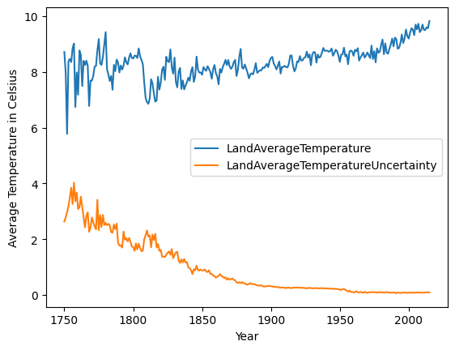

```python
global_temperatures['dt'] = pd.to_datetime(global_temperatures['dt'])
temp_df = global_temperatures.set_index('dt')
average_global_temps_yearly = temp_df.groupby([temp_df.index.year]).mean()
average_global_temps_yearly[['LandAverageTemperature', 'LandAverageTemperatureUncertainty']].plot.line(xlabel='Year', ylabel='Average Temperature in Celsius')
display(average_global_temps_yearly)
```

As we can see the difference in temperature from 1750 to 2015 may not look like much but a 1 degree difference around the world means that for many different places there could be a huge difference. I will now investigate this in the next section, where I will see what the differences are for each country.

```python
difference_from_1750_2015 = average_global_temps_yearly.iloc[-1:]['LandAverageTemperature'] - average_global_temps_yearly.iloc[0]['LandAverageTemperature']
print(f"The Difference from 1750 to 2015 is {difference_from_1750_2015.iloc[0]} Degrees Celsius in Land Temperature")
```

```
The Difference from 1750 to 2015 is 1.1116363636363626 Degrees Celsius in Land Temperature
```

**Country Temperature Averages**: In this section I can now investigate the increases for specific countries.

```
What Country Would You Like to Investigate? Argentina
```

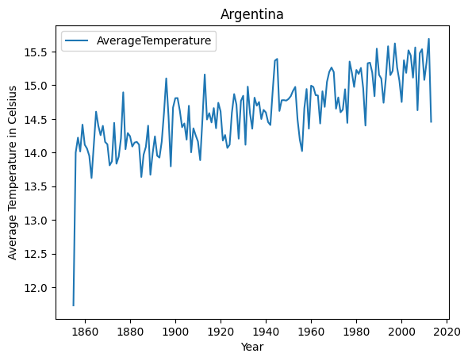

```python
global_land_temps_bycountry['dt'] = pd.to_datetime(global_land_temps_bycountry['dt'])
temps_df = global_land_temps_bycountry
# Here we group by country and year and then use the average temperature and take the mean to get the year totals, and then we rename our indexes for clarity
temps_df = temps_df.groupby([temps_df['Country'], temps_df['dt'].dt.year]).agg({'AverageTemperature':'mean'}).rename_axis(index=['Country', 'Year']).reset_index()
country = input("What Country Would You Like to Investigate? ")
temps_df[temps_df['Country'] == country].plot.line(title=country, y='AverageTemperature', x='Year', xlabel='Year', ylabel='Average Temperature in Celsius')
```

**Have You ever wondered the impact the industrial Revolution had on the climate in America?**

As seen from the graph below, it had little to no impact on the average temperature in the United States. This comes as a bit of a surprise to me because I would have thought it would have impacted the climate much more.

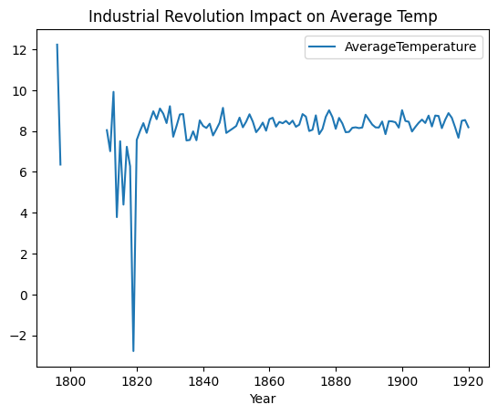

```python
industrial_rev_df = temps_df.copy()
industrial_rev_df['Year'] = industrial_rev_df['Year'].astype(int)
# We use the map here to create our mask for the loc function
mask = (
    (industrial_rev_df['Country'] == 'United States')
    & (industrial_rev_df['Year'] >= 1793)
    & (industrial_rev_df['Year'] <= 1920)
)
industrial_rev_df.loc[mask].plot.line(x='Year', y='AverageTemperature', title='Industrial Revolution Impact on Average Temp')
```

**Future Models**:

1. Model 1 would be using KNNearest neighbors to predict what the weather will look like in 50-200 years using the current global temperatures as the training and validation set. The goal would be to use enough data to predict what the weather look like for each season in the future. Will it get worse or will it get better, hopefully this model will have the answer
2. Our second model would be using the same model but instead I would want to try identify what country and city one is in based on the temperature of any year and any given day. The goal would be able to tell the model it was 13 degrees where you were on the first of march, and it would be able to give you a list of the plausible countries or cities you would be in based on that temperature.